# A3: Incarceration

```r
library(dplyr)
```

```r
library(ggplot2)
library(readr)
library(tidyr)
library(maps)
library(mapdata)
```

```r
# Load datasets
prison_pop <- read_csv("https://raw.githubusercontent.com/melaniewalsh/Neat-Datasets/main/us-prison-pop.csv")
```

```
## ──────────────────────────────────────────────────────── Delimiter: "," chr
## (3): state, county_name, urbanicity dbl (33): ...1, fips, year, total_pop,
## total_pop_15to64, total_prison_pop, f...
```

```r
colnames(prison_pop)
```

```
##  [1] "...1"                         "fips"
##  [3] "year"                         "state"
##  [5] "county_name"                  "urbanicity"
##  [7] "total_pop"                    "total_pop_15to64"
##  [9] "total_prison_pop"             "female_prison_pop"
## [11] "male_prison_pop"              "aapi_prison_pop"
## [13] "black_prison_pop"             "latinx_prison_pop"
## [15] "native_prison_pop"            "other_race_prison_pop"
## [17] "white_prison_pop"             "aapi_female_prison_pop"
## [19] "aapi_male_prison_pop"         "black_female_prison_pop"
## [21] "black_male_prison_pop"        "latinx_female_prison_pop"
## [23] "latinx_male_prison_pop"       "native_female_prison_pop"
## [25] "native_male_prison_pop"       "other_race_female_prison_pop"
## [27] "other_race_male_prison_pop"   "white_female_prison_pop"
## [29] "white_male_prison_pop"        "female_pop_15to64"
## [31] "male_pop_15to64"              "aapi_pop_15to64"
## [33] "black_pop_15to64"             "latinx_pop_15to64"
## [35] "native_pop_15to64"            "white_pop_15to64"
```

### Introduction

The trends.vera.org data tool is utilized for gathering county-level prison and jail population statistics to gain a clearer understanding of the current incarceration landscape in the U.S. The focus of the analysis is on examining trends in incarceration within the U.S. I have selected the Dataset [Dataset about prison population per county/state](https://github.com/melaniewalsh/Neat-Datasets/blob/main/us-prison-pop.csv?raw=true). This dataset offers extensive information on the prison population, including variables such as the total prison population, prison population by race (Black, White, Latinx, etc.), and by gender. These variables are essential for comprehending the disparities and trends in incarceration among different demographic groups. By analyzing this data, we can investigate how incarceration rates differ by race and gender, and how these trends have changed over time, thereby providing insights into systemic issues and highlighting areas that require policy intervention. The inclusion of detailed demographic data makes this dataset an invaluable resource for identifying patterns of inequality and guiding potential reforms in the criminal justice system.

### Summary Information

The analysis of prison populations across counties reveals that the average total prison population is approximately 361.36 individuals. The highest recorded white prison population in a single county is 9945, while the lowest is 0, indicating significant disparities. Additionally, the average male prison population is around 459.57 individuals. Over the past five years, there has been an average decrease of 1.53 in the total prison population, suggesting a slight overall decline in incarceration rates. These findings underscore the variability in incarceration across different demographics and regions.

```r
# 1. Average total prison population across all counties
average_total_prison_pop <- prison_pop %>%
  summarise(avg_total_prison_pop = mean(total_prison_pop, na.rm = TRUE))

# 2. Highest white prison population
highest_white_prison_pop <- prison_pop %>%
  filter(white_prison_pop == max(white_prison_pop, na.rm = TRUE)) %>%
  select(white_prison_pop)

# 3.Lowest White prison population
lowest_white_prison_pop <- prison_pop %>%
  filter(white_prison_pop == min(white_prison_pop, na.rm = TRUE)) %>%
  select(white_prison_pop)

# 4. Average of change in the total prison population over the past 5 years
change_over_time <- prison_pop %>%
  group_by(year) %>%
  summarise(avg_prison_pop = mean(total_prison_pop, na.rm = TRUE)) %>%
  mutate(change = avg_prison_pop - lag(avg_prison_pop))

recent_change <- change_over_time %>%
  filter(year %in% (max(year) - 4):max(year))

# Calculate the average change over the past 10 years
average_recent_change <- recent_change %>%
  summarise(avg_change = mean(change, na.rm = TRUE))



# 5. Average male prison population
average_male_prison_pop <- prison_pop %>%
  summarise(avg_male_prison_pop = mean(male_prison_pop, na.rm = TRUE))

# Print the summary values
average_total_prison_pop
```

```
## # A tibble: 1 × 1
##   avg_total_prison_pop
##                  <dbl>
## 1                 361.
```

```r
highest_white_prison_pop
```

```
## # A tibble: 1 × 1
##   white_prison_pop
##              <dbl>
## 1             9945
```

```r
lowest_white_prison_pop
```

```
## # A tibble: 1,713 × 1
##    white_prison_pop
##               <dbl>
##  1                0
##  2                0
##  3                0
##  4                0
##  5                0
##  6                0
##  7                0
##  8                0
##  9                0
## 10                0
## # ℹ 1,703 more rows
```

```r
average_recent_change
```

```
## # A tibble: 1 × 1
##   avg_change
##        <dbl>
## 1      -1.53
```

```r
average_male_prison_pop
```

```
## # A tibble: 1 × 1
##   avg_male_prison_pop
##                 <dbl>
## 1                460.
```

### The Dataset

Who collected the data?

The data was gathered from multiple sources, including the Census of Jails, Census of State and Federal Adult Correctional Facilities, FBI Uniform Crime Reporting Program, National Corrections Reporting Program, Deaths in Custody Reporting Program, Annual Survey of Jails, Centers for Disease Control, U.S. Department of Agriculture, and U.S. Census Bureau. This effort involved extensive collaboration among various organizations.

How was the data collected or generated?

The data was compiled through the collaboration of many organizations, which also supplemented it with additional information to fill in any gaps.

Why was the data collected?

The data was collected to comprehensively understand incarceration trends at the county level in the U.S. This allows for a broad understanding of jail and prison populations, though it may lack specific and precise details.

How many observations (rows) are in your data?

There are 153,811 observations (rows).

How many features (columns) are in the data?

There are 36 features (columns).

What, if any, ethical questions or questions of power do you need to consider when working with this data?

We should take this data seriously, recognizing that while there are significant differences in incarceration rates between races, it is too simplistic to conclude that this indicates racism or a racial problem. The situation is much more complex. Additionally, a high incarceration rate is not a positive indicator, so we hope to see a decreasing trend, which would suggest improved safety in the U.S.

What are possible limitations or problems with this data? (at least 200 words)

The dataset on prison populations per county/state from the Vera Institute of Justice, while comprehensive, has several limitations and potential issues. A major limitation is the presence of missing or incomplete data, as not all correctional facilities consistently report their data. This inconsistency can lead to gaps, affecting the reliability and accuracy of the analysis and causing significant variations in how different states and counties report their incarceration statistics, introducing potential biases and inaccuracies. Additionally, the dataset is historical and may not fully reflect recent changes in incarceration policies or practices. As criminal justice reform efforts gain momentum, changes such as reducing mandatory minimum sentences or decriminalizing certain offenses may not be captured, potentially misleading analyses of the current state of incarceration. Another issue is the lack of qualitative data to provide deeper insights into the reasons behind trends. Quantitative data alone cannot fully explain the socio-economic and political factors contributing to incarceration rates. Factors such as changes in law enforcement practices, economic conditions, and social movements, which are not captured in the dataset, play crucial roles. Systemic biases within the criminal justice system, like over-policing in minority communities and discriminatory sentencing practices, can also influence the data, leading to an over-representation of certain racial groups, particularly Black and Latinx populations, potentially skewing the analysis and reinforcing negative stereotypes. Moreover, the dataset does not account for the lived experiences of incarcerated individuals or the broader impact of incarceration on communities, leading to an incomplete understanding of the issue and hindering the development of holistic and effective policy solutions. Finally, interpreting the data requires careful consideration. Statistical analyses can highlight disparities but do not always explain the underlying causes. Simplistic conclusions drawn from complex data can misinform policy decisions. It is essential to approach the data with a critical and nuanced perspective, acknowledging its limitations and considering the broader socio-economic and political contexts contributing to incarceration trends. In summary, while the dataset is valuable for understanding incarceration trends in the U.S., its limitations and potential biases must be carefully managed to ensure accurate and ethical use.

### Trends Over Time Chart

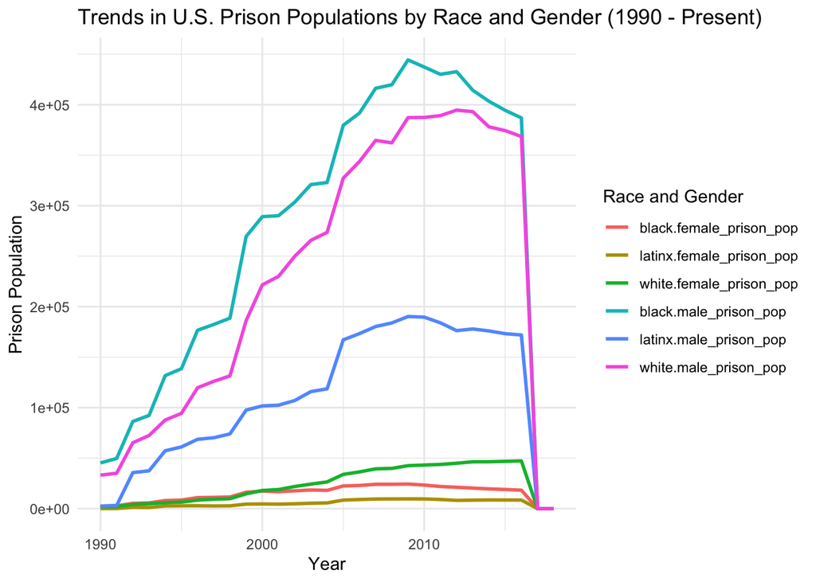

```r
trend_data_gender_race <- prison_pop %>%
  filter(year >= 1990) %>%
  group_by(year) %>%
  summarise(
    black_male_prison_pop = sum(black_male_prison_pop, na.rm = TRUE),
    black_female_prison_pop = sum(black_female_prison_pop, na.rm = TRUE),
    white_male_prison_pop = sum(white_male_prison_pop, na.rm = TRUE),
    white_female_prison_pop = sum(white_female_prison_pop, na.rm = TRUE),
    latinx_male_prison_pop = sum(latinx_male_prison_pop, na.rm = TRUE),
    latinx_female_prison_pop = sum(latinx_female_prison_pop, na.rm = TRUE)
  ) %>%
  pivot_longer(cols = c(black_male_prison_pop, black_female_prison_pop, white_male_prison_pop, white_female_prison_pop, latinx_male_prison_pop, latinx_female_prison_pop), names_to = "group", values_to = "prison_pop")

trend_data_gender_race <- trend_data_gender_race %>%
  separate(group, into = c("race", "gender"), sep = "_", extra = "merge")

ggplot(trend_data_gender_race, aes(x = year, y = prison_pop, color = interaction(race, gender), group = interaction(race, gender))) +
  geom_line(size = 1) +
  labs(
    title = "Trends in U.S. Prison Populations by Race and Gender (1990 - Present)",
    x = "Year",
    y = "Prison Population",
    color = "Race and Gender"
  ) +
  theme_minimal()
```

### Variable Comparison Chart

This chart illustrates the relationship between the total prison population and the female prison population, visually representing how the female prison population correlates with the overall prison population. The inclusion of this chart is crucial for analyzing gender dynamics within the prison system and identifying patterns that may inform policy decisions and reforms. The chart reveals a positive correlation between the total prison population and the female prison population, with the female population increasing as the total population increases. The linear regression line (in blue) indicates a strong linear relationship between the two variables, suggesting that changes in the total prison population are reflected in changes in the female prison population. This visualization provides a clear picture of how the female prison population scales with the total prison population, highlighting the proportional representation of female inmates and assisting in understanding the broader gender-related trends within the prison system.

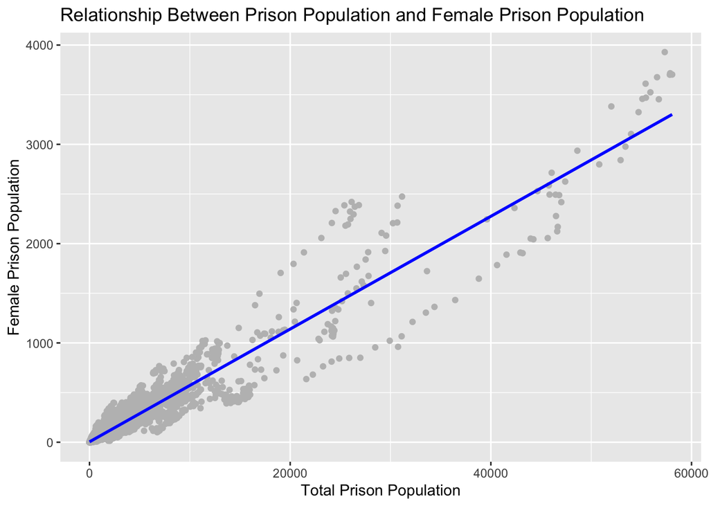

```r
prison_pop <- read_csv("https://raw.githubusercontent.com/melaniewalsh/Neat-Datasets/main/us-prison-pop.csv")
chart2_data <- prison_pop %>%
  filter(!is.na(total_prison_pop) & !is.na(female_prison_pop))

ggplot(data = chart2_data, aes(x = total_prison_pop, y = female_prison_pop)) +
  geom_point(color = "grey") +
  geom_smooth(method=lm, color= "blue",  se=FALSE) +
  labs(title = paste("Relationship Between Prison Population and Female",
                     "Prison Population"),
       x = "Total Prison Population",
       y = "Female Prison Population")
```

### Map

This map shows the geographic distribution of the total prison population across different states in the United States, visually representing how prison populations are distributed geographically and providing insights into regional patterns and disparities. The inclusion of this map aims to offer a clear visual representation of these patterns, which is crucial for identifying areas with high incarceration rates and informing policy decisions to address these disparities. The map reveals significant regional concentrations of prison populations, with states in darker shades of blue indicating higher total prison populations. There is considerable variability across states, highlighting disparities influenced by state-specific policies, economic conditions, and other factors. This visualization helps identify regions with higher incarceration rates and contributes to a better understanding of the factors influencing these patterns.

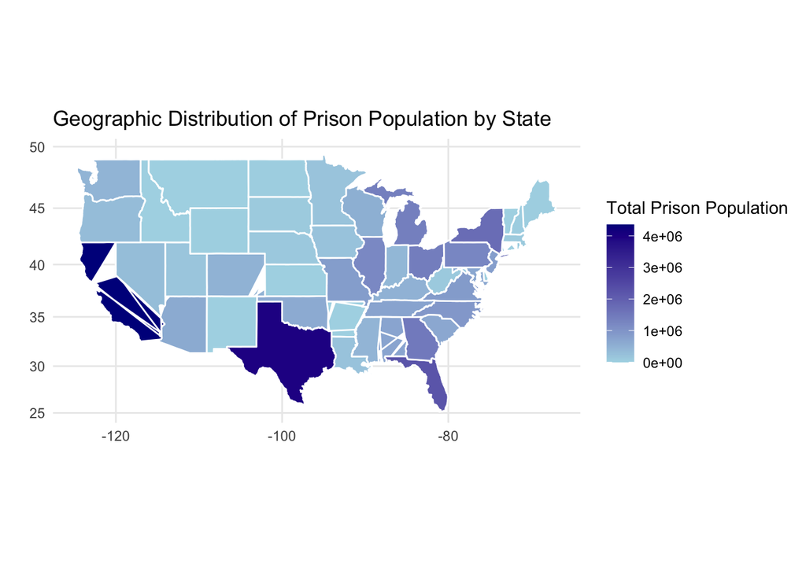

```r
library(dplyr)
library(ggplot2)
library(readr)
library(maps)

prison_pop <- read_csv("https://raw.githubusercontent.com/melaniewalsh/Neat-Datasets/main/us-prison-pop.csv")

state_prison_pop <- prison_pop %>%
  group_by(state) %>%
  summarise(total_prison_pop = sum(total_prison_pop, na.rm = TRUE))

states_map <- map_data("state")

state_prison_pop$state <- tolower(state.name[match(state_prison_pop$state, state.abb)])

map_data_prison <- merge(states_map, state_prison_pop, by.x = "region", by.y = "state", all.x = TRUE)

ggplot(data = map_data_prison, aes(x = long, y = lat, group = group, fill = total_prison_pop)) +
  geom_polygon(color = "white") +
  scale_fill_continuous(name = "Total Prison Population", low = "lightblue", high = "darkblue") +
  labs(
    title = "Geographic Distribution of Prison Population by State",
    x = "",
    y = ""
  ) +
  coord_map() +
  theme_minimal()
```